# 04_simulations

Sean Maden

2023-11-22

Results from pseudobulk simulations using Plasmablast and Non-plasmablast cell proportions from Monaco et al 2019.

# Background

## Simulations

In addition, the following data were drawn from the experiment: 1. Proportions were calculated for each category from flow cytometry proportions; 2. Mean expression was calculated from bulk RNA-seq TPM data at ABIS-seq marker genes.

# Pseudobulk preparation

Simulations were run for 12 (N = 12) donors with available known cell type proportions from flow cytometry. In total, data from 17 (N = 17) cell types were used, where 16 were aggregated under “non-plasmablast”, and “plasmablast” was retained.

# Pseudobulk properties

## Cell size calculations

Cell size scale factors obtained as the library sizes (column sums) from the RNA-seq reference in Monaco et al 2019 (Table S5). Binarized cell sizes (Plasmablasts, Non-plasmablasts) for Non-plasmablasts were taken as the median of cell sizes.

# Scatter plots of simulation outcomes

Reporting pseudobulk results, at 3 zoom levels.

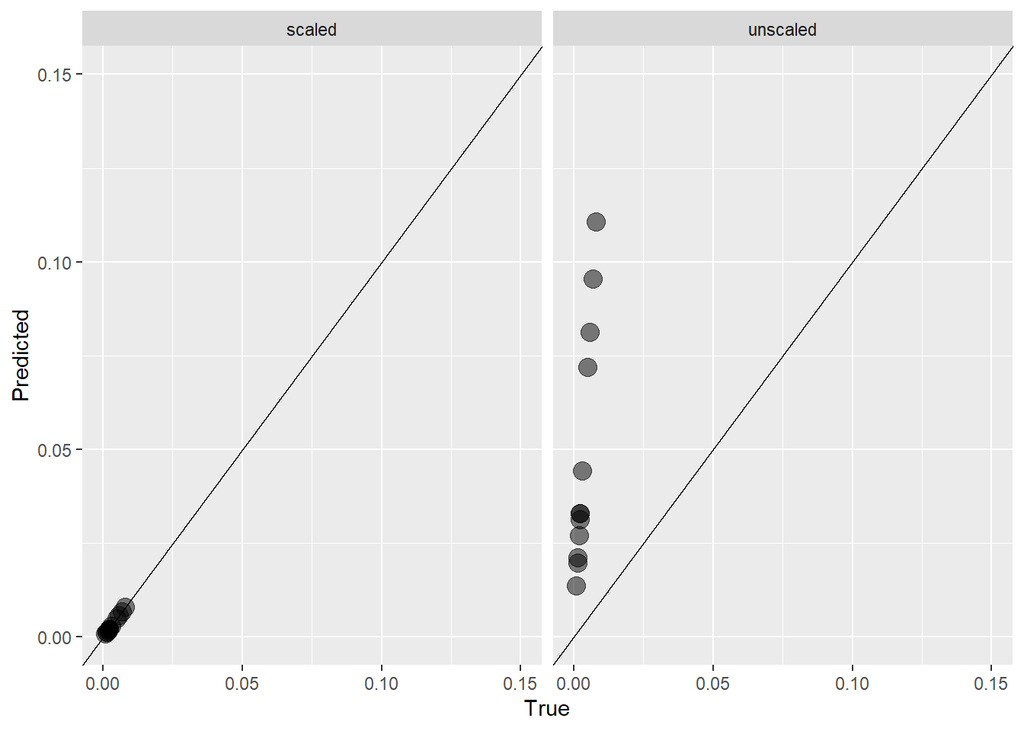

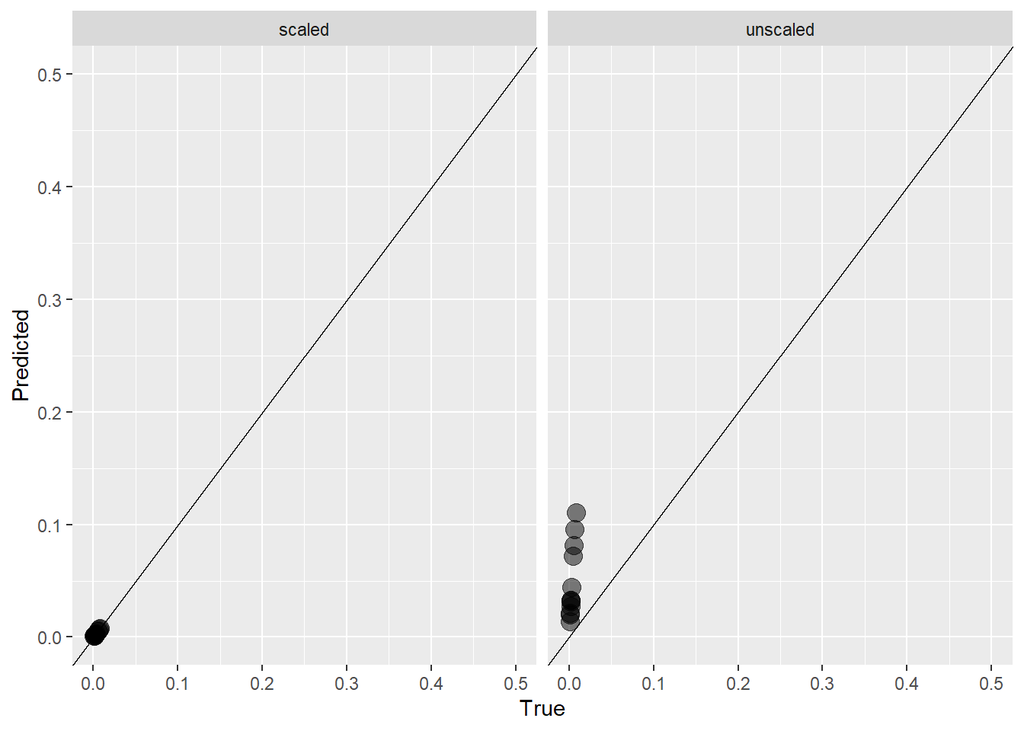

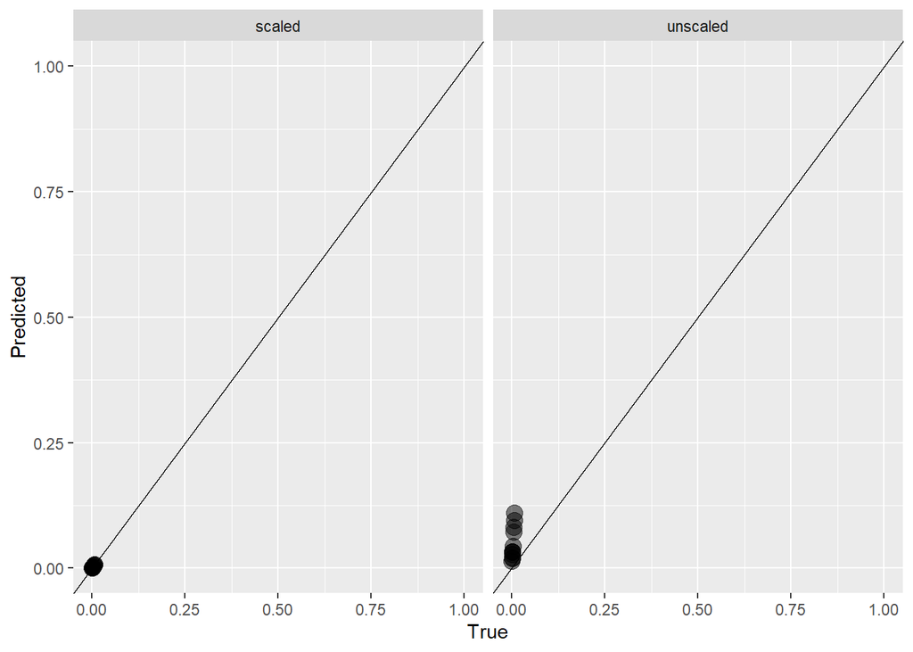

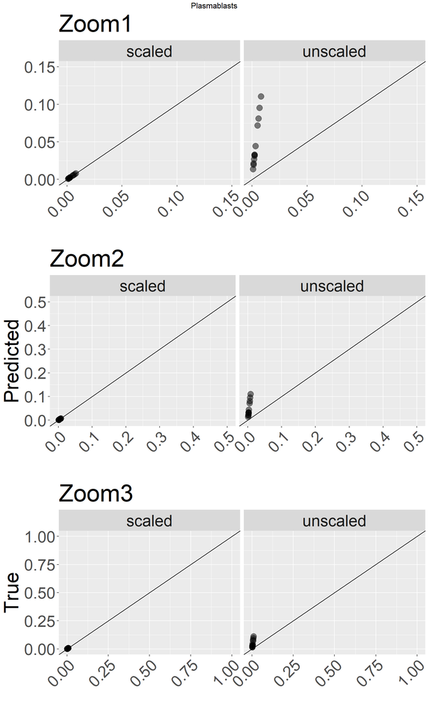

# Save

```
## [1] "01_pseudobulk"
```